# Monte Carlo Mix

# (1) Get the data

# (2) Get all simulation parameters

## Get all the real data useful for our modelisation

## Simulation with hyper-parameters

```
## [1] "patient :WAS4|m48"
```

```
## [1] "cst_variance : 1 || pourcentage BMGKT : 1 || pourcentage GM  0 pourcentageT  0 || cst_ab pour le sampling : 1000"
```

# (3) Monte Carlo loop

```
## [1] "Monte Carlo replicates = 50"
```

```
## [1] "Monte Carlo m= 1"
## [1] "Monte Carlo m= 2"
## [1] "Monte Carlo m= 3"
## [1] "Monte Carlo m= 4"
## [1] "Monte Carlo m= 5"
## [1] "Monte Carlo m= 6"
## [1] "Monte Carlo m= 7"
## [1] "Monte Carlo m= 8"
## [1] "Monte Carlo m= 9"
## [1] "Monte Carlo m= 10"
## [1] "Monte Carlo m= 11"
## [1] "Monte Carlo m= 12"
## [1] "Monte Carlo m= 13"
## [1] "Monte Carlo m= 14"
## [1] "Monte Carlo m= 15"
```

[output cut: 35 more lines]

```
## [1] "Time for 50 Monte Carlo replicates= 29 min"
```

```r
indic_sim=data.frame(n_sim = c(1:M),means,vars,nbIS,nb_cells)
print(indic_sim)
```

n_sim means vars nbIS nb_cells 1 1 9.031060 181.0669 9530 86066 2 2 9.045478 184.4169 9521 86122 3 3 9.042441 184.7549 9519 86075 4 4 9.089193 185.5481 9485 86211 5 5 9.025289 181.5627 9530 86011 6 6 9.134526 187.9784 9448 86303 7 7 9.025464 184.3579 9543 86130 8 8 9.087438 186.8587 9481 86158 9 9 9.105686 186.9044 9462 86158 10 10 9.086383 184.8215 9481 86148 11 11 9.089193 185.5481 9485 86211 12 12 9.025289 181.5627 9530 86011 13 13 9.134526 187.9784 9448 86303 14 14 9.025464 184.3579 9543 86130 15 15 9.087438 186.8587 9481 86158 16 16 9.105686 186.9044 9462 86158 17 17 9.086383 184.8215 9481 86148 18 18 9.089193 185.5481 9485 86211 19 19 9.025289 181.5627 9530 86011 20 20 9.134526 187.9784 9448 86303 21 21 9.025464 184.3579 9543 86130 22 22 9.087438 186.8587 9481 86158 23 23 9.105686 186.9044 9462 86158 24 24 9.086383 184.8215 9481 86148 25 25 9.089193 185.5481 9485 86211 26 26 9.025289 181.5627 9530 86011 27 27 9.134526 187.9784 9448 86303 28 28 9.025464 184.3579 9543 86130 29 29 9.087438 186.8587 9481 86158 30 30 9.105686 186.9044 9462 86158 31 31 9.086383 184.8215 9481 86148 32 32 9.089193 185.5481 9485 86211 33 33 9.025289 181.5627 9530 86011 34 34 9.134526 187.9784 9448 86303 35 35 9.025464 184.3579 9543 86130 36 36 9.087438 186.8587 9481 86158 37 37 9.105686 186.9044 9462 86158 38 38 9.086383 184.8215 9481 86148 39 39 9.089193 185.5481 9485 86211 40 40 9.025289 181.5627 9530 86011 41 41 9.134526 187.9784 9448 86303 42 42 9.025464 184.3579 9543 86130 43 43 9.087438 186.8587 9481 86158 44 44 9.105686 186.9044 9462 86158 45 45 9.086383 184.8215 9481 86148 46 46 9.089193 185.5481 9485 86211 47 47 9.025289 181.5627 9530 86011 48 48 9.134526 187.9784 9448 86303 49 49 9.025464 184.3579 9543 86130 50 50 9.087438 186.8587 9481 86158

```r
cat('\n')
```

```r
#Mean Ab
indic_to_show=tibble(indic$mean_cells, mean(indic_sim$means), sd(indic_sim$means))
colnames(indic_to_show)=c('real mean Abundance','Mean on the 50 trials','SD on the 50 trials')
print(kable(indic_to_show)%>%kable_styling())
```

| real mean Abundance | Mean on the 50 trials | SD on the 50 trials |
| --- | --- | --- |
| 5.226183 | 9.076095 | 0.038333 |

```r
cat('\n')
```

```r
#Var Ab
indic_to_show=tibble(indic$var, mean(indic_sim$vars), sd(indic_sim$vars))
colnames(indic_to_show)=c('real var Abundance','Mean on the 50 trials','SD on the 50 trials')
print(kable(indic_to_show)%>%kable_styling())
```

| real var Abundance | Mean on the 50 trials | SD on the 50 trials |
| --- | --- | --- |
| 285.3027 | 185.2947 | 2.057602 |

```r
cat('\n')
```

```r
#nb IS
indic_to_show=tibble(indic$UniqueSites, mean(indic_sim$nbIS), sd(indic_sim$nbIS))
colnames(indic_to_show)=c('real nb of IS','Mean on the 50 trials','SD on the 50 trials')
print(kable(indic_to_show)%>%kable_styling())
```

| real nb of IS | Mean on the 50 trials | SD on the 50 trials |
| --- | --- | --- |
| 10465 | 9492.74 | 32.62953 |

```r
cat('\n')
```

```r
#nb cells
indic_to_show=tibble(indic$Inferred_cells, mean(indic_sim$nb_cells), sd(indic_sim$nb_cells))
colnames(indic_to_show)=c('real nb of cells','Mean on the 50 trials','SD on the 50 trials')
print(kable(indic_to_show)%>%kable_styling())
```

| real nb of cells | Mean on the 50 trials | SD on the 50 trials |
| --- | --- | --- |
| 54692 | 86155.8 | 83.37229 |

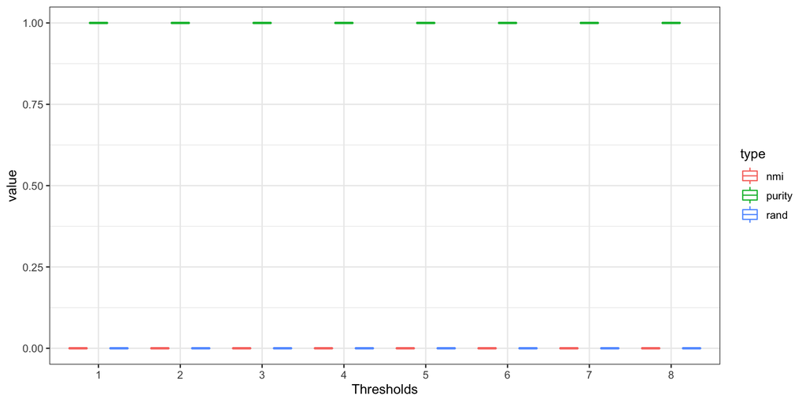

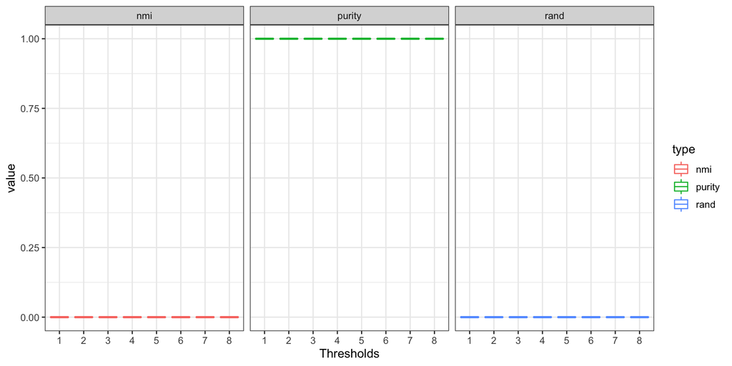

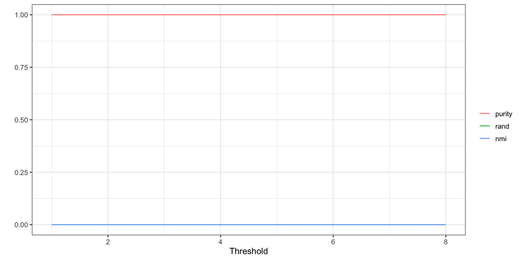

```r
cat('\n')
```